# **Credit Risk Modeling - Monitoring**

In this part of our work, we are going to preprocess a new data to determine whether the population has changed and assess whether we can keep the original PD model or rebuild the model.  
We will introduce the population stability index (PSI) as a measure that evaluates two popuations. PSI can be used to assess whether the population of new loan applicants differs from the population of applicants on which the PD model was built. The formula below is used ti calculate the PSI:

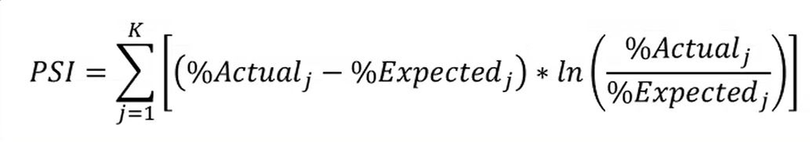

### **Import libraries**

```python
import numpy as np
import pandas as pd

import matplotlib.pyplot as plt
import seaborn as sns
sns.set()
```

```python
# load the original (actual) population
loan_inputs_train = pd.read_csv('C:/Users/Aylan/Documents/IT/Datasets/loan_data_inputs_train.csv', index_col = 0)
loan_targets_train = pd.read_csv('C:/Users/Aylan/Documents/IT/Datasets/loan_data_targets_train.csv', index_col = 0)
loan_inputs_test = pd.read_csv('C:/Users/Aylan/Documents/IT/Datasets/loan_data_inputs_test.csv', index_col = 0)
loan_targets_test = pd.read_csv('C:/Users/Aylan/Documents/IT/Datasets/loan_data_targets_test.csv', index_col = 0)

# next, let's import the dataset of 2015
loan_data_2015_backup = pd.read_csv('C:/Users/Aylan/Documents/IT/Datasets/loan_data_2015.csv')

# copy the "loan_data_2015" dataframe
loan_data_2015 = loan_data_2015_backup.copy()

# display the the first rows of "loan_data_2015"
pd.options.display.max_columns = None
loan_data_2015.head()
```

|  | id | member_id | loan_amnt | funded_amnt | funded_amnt_inv | term | int_rate | installment | grade | sub_grade | emp_title | emp_length | home_ownership | annual_inc | verification_status | issue_d | loan_status | pymnt_plan | url | desc | purpose | title | zip_code | addr_state | dti | delinq_2yrs | earliest_cr_line | inq_last_6mths | mths_since_last_delinq | … |
| --- | --- | --- | --- | --- | --- | --- | --- | --- | --- | --- | --- | --- | --- | --- | --- | --- | --- | --- | --- | --- | --- | --- | --- | --- | --- | --- | --- | --- | --- | --- |
| 0 | 68444620 | 73334399 | 35000 | 35000 | 35000.0 | 60 months | 11.99 | 778.38 | C | C1 | Foreign Service Officer | 10+ years | MORTGAGE | 128000.0 | Source Verified | Dec-15 | Issued | n | https://www.lendingclub.com/browse/loanDetail.... | NaN | home_improvement | Home improvement | 200xx | DC | 6.46 | 0.0 | Feb-90 | 0.0 | 46.0 | … |
| 1 | 68547583 | 73437441 | 8650 | 8650 | 8650.0 | 36 months | 5.32 | 260.50 | A | A1 | Associate Consultant | < 1 year | MORTGAGE | 100000.0 | Not Verified | Dec-15 | Issued | n | https://www.lendingclub.com/browse/loanDetail.... | NaN | credit_card | Credit card refinancing | 462xx | IN | 7.28 | 0.0 | Jul-01 | 0.0 | NaN | … |
| 2 | 67849662 | 72708407 | 4225 | 4225 | 4225.0 | 36 months | 14.85 | 146.16 | C | C5 | mechanic | 5 years | RENT | 35000.0 | Source Verified | Dec-15 | Issued | n | https://www.lendingclub.com/browse/loanDetail.... | NaN | debt_consolidation | Debt consolidation | 672xx | KS | 15.22 | 2.0 | Jul-11 | 0.0 | 18.0 | … |
| 3 | 68506885 | 73396712 | 10000 | 10000 | 10000.0 | 60 months | 11.99 | 222.40 | C | C1 | CARDIOVASCULAR TECH | 10+ years | RENT | 42500.0 | Not Verified | Dec-15 | Issued | n | https://www.lendingclub.com/browse/loanDetail.... | NaN | debt_consolidation | Debt consolidation | 460xx | IN | 31.04 | 0.0 | Dec-98 | 1.0 | NaN | … |
| 4 | 68341763 | 72928789 | 20000 | 20000 | 20000.0 | 60 months | 10.78 | 432.66 | B | B4 | truck driver | 10+ years | MORTGAGE | 63000.0 | Not Verified | Dec-15 | Issued | n | https://www.lendingclub.com/browse/loanDetail.... | NaN | home_improvement | NaN | 605xx | IL | 10.78 | 0.0 | Aug-00 | 0.0 | NaN | … |

### **Population Stability Index: Preprocessing**

We need to preprocess the new data the same way we preprocessed the train and test data. Since we already have such a code, we can reuse it from the "Credit Risk Modeling - Part 1" notebook.

**>>> The code from here to the other line starting with ">>>" is copied from the "Credit Risk Modeling - Part 1" notebook, with some adjustments. We have to perform exactly the same data preprocessing, fine classing and coarse classing on the new data, in order to be able to calculate statistics for the exact same variables to the ones we used for training and testing the PD model.**